# WBData

Samiratou Kora Chabi

```r
getwd()
```

```
## [1] "C:/Users/Admin/Desktop/World_Bank"
```

# Check installed packages

```r
installed.packages(c("styler","lintr","WDI","ggplot2","rmarkdown","reshape2","dplyr","tidyr","knit"))
```

```
##      Package LibPath Version Priority Depends Imports LinkingTo Suggests
##      Enhances License License_is_FOSS License_restricts_use OS_type Archs
##      MD5sum NeedsCompilation Built
```

# Load packages

```r
library(knitr)
library(rmarkdown)
library(styler)
library(lintr)
library(WDI)
library(ggplot2)
library(reshape2)
library(dplyr)
library(tidyr)
```

# Dowload series for some countries using world bank gender data portal

## Load data about account ownership in some countries of west africa

**Definition of variable**

*FX.OWN.TOTL.FE.ZS: Account ownership at a financial institution or with a mobile-money-service provider, female (% of population ages 15+)

```r
dat = WDI(indicator='FX.OWN.TOTL.FE.ZS', country=c('CMR','BFA','BEN'), start=2010, end=2020)
```

```r
dat1 = WDI(indicator='FX.OWN.TOTL.FE.ZS', country=c('CMR','BEN','SEN'), start=2010, end=2020)
```

**List of variables**

*SL.EMP.MPYR.FE.ZS: Employers, female (% of female employment)

*SL.EMP.MPYR.MA.ZS: Employers, male (% of male employment)

*SL.EMP.MPYR.ZS: Employers, total (% of total employment)

*SL.AGR.EMPL.ZS: Employment in agriculture (% of total employment)

*SL.AGR.EMPL.FE.ZS: Employment in agriculture, female (% of female employment)

*SL.AGR.EMPL.MA.ZS: Employment in agriculture, male (% of male employment)

*SL.IND.EMPL.ZS: Employment in industry (% of total employment)

*SL.IND.EMPL.FE.ZS: Employment in industry, female (% of female employment)

*SL.IND.EMPL.MA.ZS: Employment in industry, male (% of male employment)

*SL.SRV.EMPL.ZS: Employment in services (% of total employment)

*SL.SRV.EMPL.FE.ZS: Employment in services, female (% of female employment)

*SL.SRV.EMPL.MA.ZS: Employment in services, male (% of male employment)

```r
dat2=WDI(indicator=c('SL.EMP.MPYR.FE.ZS','SL.EMP.MPYR.MA.ZS','SL.EMP.MPYR.ZS','SL.AGR.EMPL.ZS','SL.AGR.EMPL.FE.ZS','SL.AGR.EMPL.MA.ZS','SL.IND.EMPL.ZS','SL.IND.EMPL.FE.ZS','SL.IND.EMPL.MA.ZS','SL.SRV.EMPL.ZS','SL.SRV.EMPL.FE.ZS','SL.SRV.EMPL.MA.ZS'),country=c('CAN','MEX','FRA','USA'),start=2010, end=2019)

dat2=WDI(indicator=c('SL.EMP.MPYR.FE.ZS
'),country=c('CAN','MEX','FRA','USA'),start=2010, end=2019)
```

# Look at the data

```r
head(dat)
```

```
##   iso2c country FX.OWN.TOTL.FE.ZS year
## 1    BJ   Benin                NA 2020
## 2    BJ   Benin                NA 2019
## 3    BJ   Benin                NA 2018
## 4    BJ   Benin          28.58589 2017
## 5    BJ   Benin                NA 2016
## 6    BJ   Benin                NA 2015
```

```r
head (dat1)
```

```
##   iso2c country FX.OWN.TOTL.FE.ZS year
## 1    BJ   Benin                NA 2020
## 2    BJ   Benin                NA 2019
## 3    BJ   Benin                NA 2018
## 4    BJ   Benin          28.58589 2017
## 5    BJ   Benin                NA 2016
## 6    BJ   Benin                NA 2015
```

```r
head (dat2)
```

```
##   iso2c country SL.EMP.MPYR.FE.ZS\n year
## 1    CA  Canada                2.59 2019
## 2    CA  Canada                2.71 2018
## 3    CA  Canada                2.59 2017
## 4    CA  Canada                2.61 2016
## 5    CA  Canada                2.70 2015
## 6    CA  Canada                2.61 2014
```

# Plot the data using dataset dat1

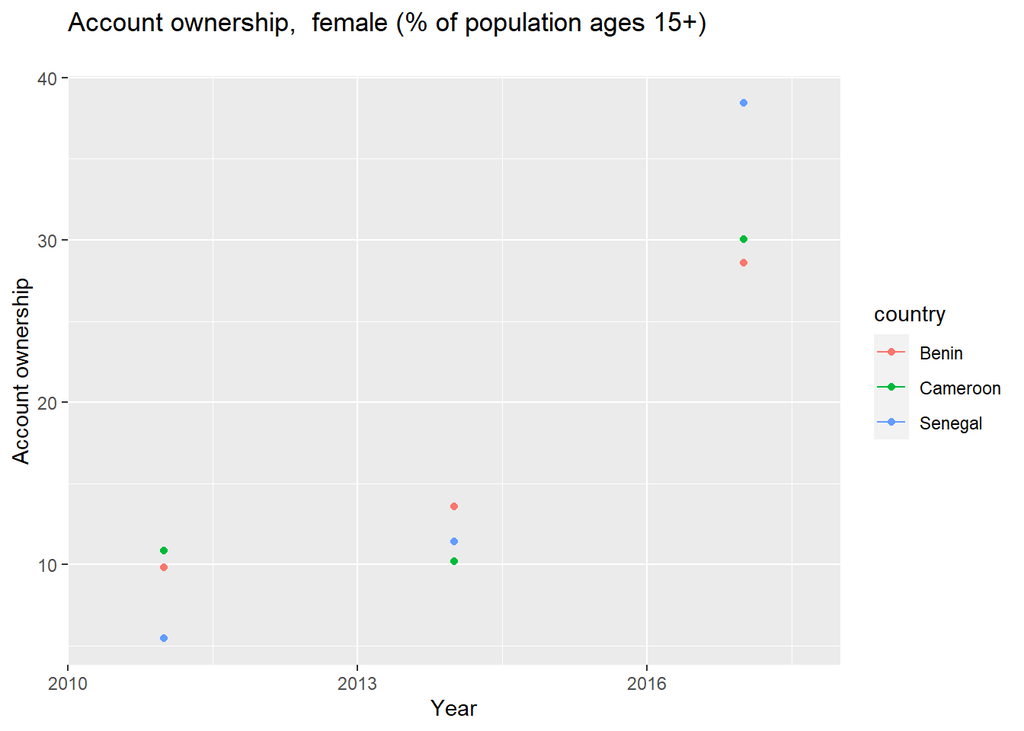

```r
dat1 = WDI(indicator='FX.OWN.TOTL.FE.ZS', country=c('CMR','BEN','SEN'), start=2010, end=2020)

ggplot(dat1, aes(year, FX.OWN.TOTL.FE.ZS, color=country, group=country)) + geom_line() +
  xlab('Year') + ylab('Account ownership') +
  scale_x_continuous(limits=c(2010, 2018), breaks = seq(2010, 2018, 3),
                     expand = c(0, 0)) + geom_point(na.rm = TRUE)+
  ggtitle("Account ownership,  female (% of population ages 15+)
")
```

# Plot the data using dataset dat2

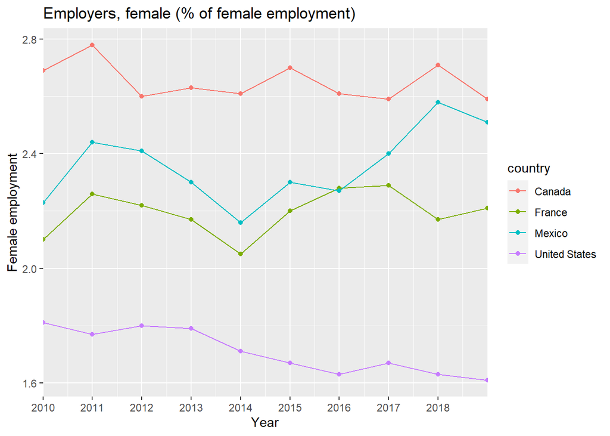

```r
dat2=WDI(indicator=c('SL.EMP.MPYR.FE.ZS','SL.EMP.MPYR.MA.ZS','SL.EMP.MPYR.ZS','SL.AGR.EMPL.ZS','SL.AGR.EMPL.FE.ZS','SL.AGR.EMPL.MA.ZS','SL.IND.EMPL.ZS','SL.IND.EMPL.FE.ZS','SL.IND.EMPL.MA.ZS','SL.SRV.EMPL.ZS','SL.SRV.EMPL.FE.ZS','SL.SRV.EMPL.MA.ZS'),country=c('CAN','MEX','FRA','USA'),start=2010, end=2019)

ggplot(data = dat2, aes(x = year, y = SL.EMP.MPYR.FE.ZS, color = country)) +
  geom_line(aes(color= country))+ geom_point(na.rm = TRUE)+
  scale_x_continuous(limits=c(2010, 2019), breaks = seq(2010, 2018, 1),
                     expand = c(0, 0)) +
  xlab('Year') + ylab('Female employment') +
  ggtitle("Employers, female (% of female employment)")
```

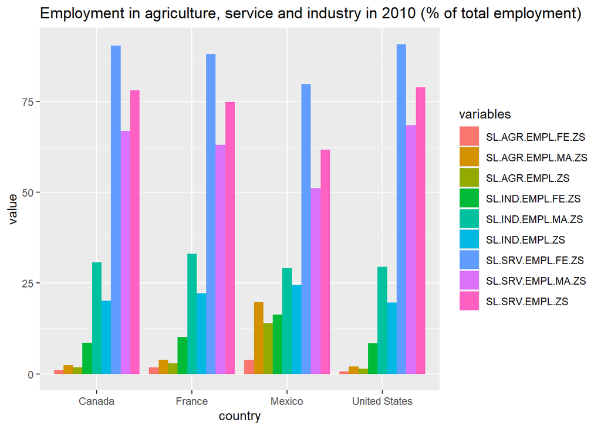

```r
dat2$id<-1:nrow(dat2)
dat2m10<-pivot_longer(subset(dat2,year==2010), -c(country,year,iso2c,id,'SL.EMP.MPYR.FE.ZS','SL.EMP.MPYR.MA.ZS','SL.EMP.MPYR.ZS'), names_to="variables", values_to="value")

dat2m19<-pivot_longer(subset(dat2,year==2019), -c(country,year,iso2c,id,'SL.EMP.MPYR.FE.ZS','SL.EMP.MPYR.MA.ZS','SL.EMP.MPYR.ZS'), names_to="variables", values_to="value")

ggplot(dat2m10,aes(x = country,y = value)) +
    geom_bar(aes(fill = variables),stat = "identity",position = "dodge")+
  ggtitle("Employment in agriculture, service and industry in 2010 (% of total employment)")
```

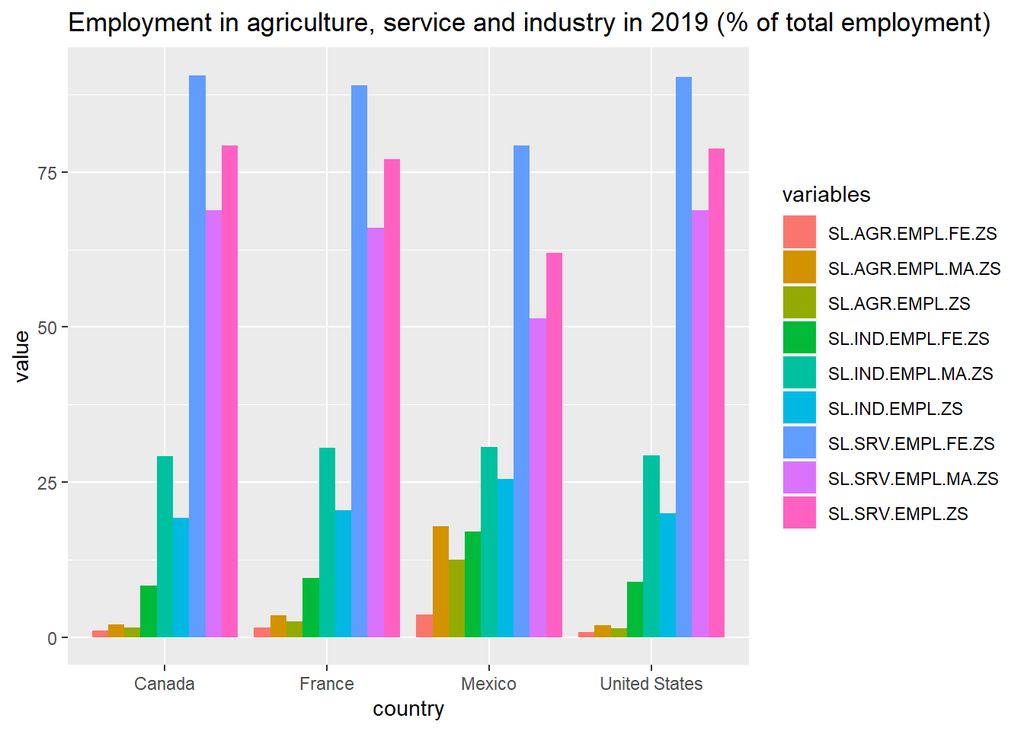

```r
ggplot(dat2m19,aes(x = country,y = value)) +
    geom_bar(aes(fill = variables),stat = "identity",position = "dodge")+
  ggtitle("Employment in agriculture, service and industry in 2019 (% of total employment)")
```